# Analisis 2

Gustavo Amador Fonseca C20451

2025-05-28

# Limpieza de Datos

```r
#Creación de copia del df original (crudo)
data_clean <- data_raw
names(data_clean)[9] <- "Dengue Diagnosis"
#View(data_clean)
```

# Análisis de correlaciones entre variables predictores

Recordar que el enálisis es para variables que se realcione con la pregunta, por eso se descarta edad y sexo.

Para esto se considera la matriz de correlación de Pearson calculada entre todas las variables numéricas del conjunto de datos, incluyendo variables continuas y binarias codificadas como 0 y 1. El análisis de esta matriz permite identificar relaciones lineales entre los predictores y detectar posibles casos de colinealidad que podrían afectar los modelos estadísticos posteriores.

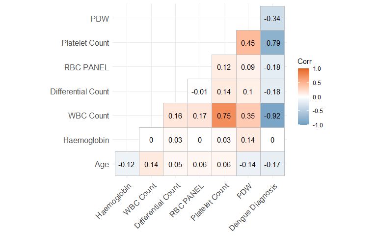

Entre los hallazgos más relevantes destaca la **fuerte correlación positiva** (r = 0.75) entre el recuento de glóbulos blancos (*WBC Count*) y el recuento de plaquetas (*Platelet Count*). Esta relación indica la posibilidad de que ambas variables sean afectadas simultáneamente por procesos clínicos relacionados. Esta asociación también alerta sobre una posible **colinealidad**, que deberá ser considerada en la selección de predictores.

También se observa una correlación menos fuerte (r = 0.45) entre *Platelet Count* y *PDW*, lo que indica una posible relación entre la cantidad de plaquetas y la variabilidad de su tamaño, esto puede tener implicaciones biológicas.

En cambio, la variable *Hemoglobin* presenta correlaciones muy bajas con el resto de variables (r ≈ 0), lo que sugiere que no está linealmente asociada con los otros marcadores hematológicos. No obstante, esto no es indicador de poca importancia al momento de ajustar un modelo estadístico. Las variables binarias como *Differential Count* y *RBC PANEL* muestran correlaciones bajas con las demás, aunque mantienen leves asociaciones positivas con *WBC Count* y *Platelet Count*, lo que podría reflejar su rol como indicadores clínicos consolidados de riesgo hematológico.

También se puede observar correlaciones ligeras con la variable edad (Age) y los indicadores hematológicos, lo cual tambien puede sugerir que estos pueden variar por con forme las personas avanzan de edad por razones biológicas. Sin embargo, la variable edad como la de sexo no son consieradas en este análisis, ya que no forman parte de variables hematológicas. Este análisis inicial de correlación proporciona una base para la selección de variables y justifica decisiones metodológicas posteriores, como la eliminación de predictores redundantes o el uso de técnicas que controlen multicolinealidad.

# Análisis de variables binarias

## Dengue Diagnosis

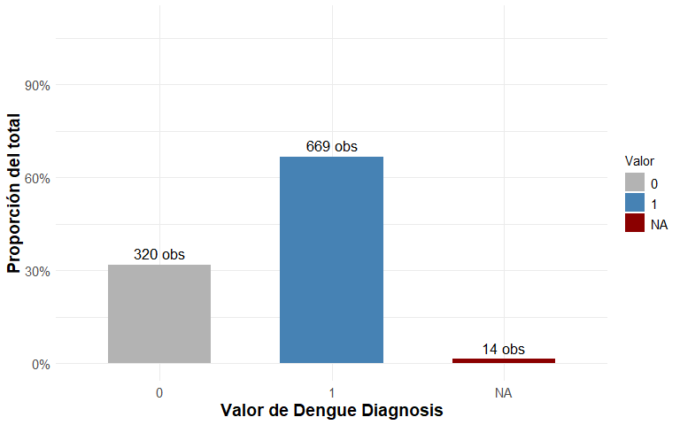

La variable `Dengue Diagnosis`, que representa la presencia o ausencia de diagnóstico positivo por dengue, muestra un desequilibrio en la distribución de clases. Según se observa en el gráfico, un total de 669 observaciones (66.7%) corresponden a casos positivos (valor 1), mientras que 320 observaciones (32%) corresponden a casos negativos (valor 0). Además, existen 14 registros sin información (NA), lo cual representa un 1.4% del total de datos, siendo una cantidad poco significativa en la base de datos.

Se evidencia un sesgo hacia los casos positivos, sugiriendo que la muestra está centrada en pacientes que presentaron síntomas compatibles con la enfermedad, lo cual es esperable. No obstante, este desbalance debe ser considerado en la selección y evaluación de modelos estadísticos, ya que podría afectar el rendimiento y la interpretación de los resultados.

Asimismo, la presencia de observaciones faltantes (NA) deberá ser abordada en el proceso de limpieza o imputación de datos, dependiendo del enfoque metodológico que se adopte.

## Differential Count

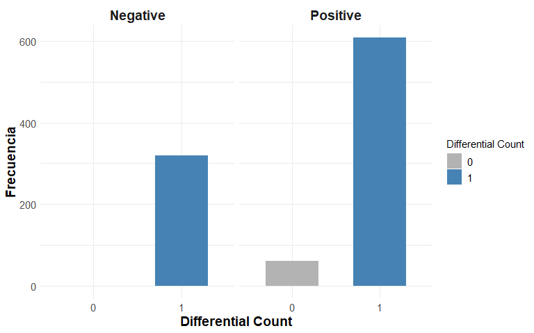

El gráfico muestra la distribución de la variable `Differential Count` según el diagnóstico de dengue. En ambos grupos (diagnóstico positivo y negativo), se observa una mayor frecuencia de pacientes con `Differential Count = 1`, lo que indica que las alteraciones en el conteo diferencial de leucocitos son comunes en la muestra.

Sin embargo, dado el desbalance en el número de observaciones entre los grupos (mayoría de casos positivos), esta diferencia debe interpretarse con cuidado. Para evaluar si esta variable tiene valor discriminativo real, sería necesario complementar el análisis visual con una medida de asociación relativa o aplicar un modelo que controle por el desequilibrio de clases.

## RBC PANEL

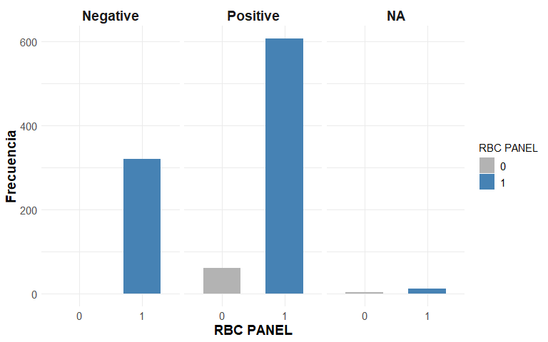

En la distribución de la variable `RBC PANEL` según el diagnóstico de dengue, se observa que la mayoría de los pacientes presentan alteraciones en el panel eritrocitario (`RBC PANEL = 1`), tanto en el grupo con dengue como en el grupo sin diagnóstico.

Aunque el grupo positivo concentra una mayor cantidad de casos con `RBC PANEL = 1`, esta tendencia debe interpretarse con cautela debido al desequilibrio en el número de observaciones entre los grupos. En términos generales, el gráfico sugiere que las alteraciones en el panel de glóbulos rojos son frecuentes en la muestra, pero no muestra una diferenciación visual clara entre los estados diagnósticos.

# Análisis de variables numéricas

## Análisis descriptivo comparativo por grupo de diagnóstico

Con el objetivo de identificar patrones relevantes entre variables hematológicas y el diagnóstico de dengue, se presentan a continuación los estadísticos descriptivos agrupados según el resultado de la variable Final Dengue Dianosis. Estas comparaciones permiten explorar si existen diferencias sustanciales entre pacientes con y sin dengue, que puedan justificar su inclusión en metodologías estadísticas posteriores.

### Hemoglobin

```
## # A tibble: 3 × 4
##   `Dengue Diagnosis` Haemoglobin_mean Haemoglobin_sd Haemoglobin_median
##                <dbl>            <dbl>          <dbl>              <dbl>
## 1                  0             13.7           1.53               13.8
## 2                  1             13.7           1.47               13.7
## 3                 NA             13.1           1.28               13.6
```

En promedio, los niveles de hemoglobina son similares entre pacientes con y sin diagnóstico de dengue (13.71 vs 13.72 g/dL), con medianas prácticamente iguales y una ligera mayor dispersión en el grupo sin dengue. Estas diferencias no parecen clínicamente relevantes, lo que sugiere que la hemoglobina no es un buen discriminador entre los grupos analizados.

### WBC_Count

```
## # A tibble: 3 × 4
##   `Dengue Diagnosis` WBC_Count_mean WBC_Count_sd WBC_Count_median
##                <dbl>          <dbl>        <dbl>            <dbl>
## 1                  0          7448.        1478.             7500
## 2                  1          2852.         494.             2900
## 3                 NA          3064.         496.             3150
```

Los pacientes con diagnóstico positivo de dengue presentan un recuento promedio de glóbulos blancos notablemente menor (2851.91 células/µL) en comparación con quienes no tienen dengue (7448.40 células/µL). Esta diferencia también se refleja en las medianas (2900 vs 7500) y en una menor dispersión. Estas observaciones sugieren que el recuento de leucocitos podría ser útil para discriminar entre casos positivos y negativos de dengue.

### Platelet Count

```
## # A tibble: 3 × 4
##   `Dengue Diagnosis` Platelet_Count_mean Platelet_Count_sd Platelet_Count_median
##                <dbl>               <dbl>             <dbl>                 <dbl>
## 1                  0             216247.            78897                 180000
## 2                  1              65862.            38770.                 64000
## 3                 NA              76815.            31072.                 83000
```

Los pacientes con diagnóstico de dengue presentan un recuento de plaquetas mucho menor (media: 65,862; mediana: 64,000) en comparación con los pacientes sin dengue (media: 216,246; mediana: 180,000). Además, la dispersión es más alta en el grupo sin dengue. Estas diferencias refuerzan el potencial del recuento plaquetario como variable útil para discriminar casos positivos.

### PDW

```
## # A tibble: 3 × 4
##   `Dengue Diagnosis` PDW_mean PDW_sd PDW_median
##                <dbl>    <dbl>  <dbl>      <dbl>
## 1                  0     30.3  16.1          35
## 2                  1     19.3  12.5          17
## 3                 NA     15.3   3.24         16
```

El valor de PDW, que representa la variabilidad en el tamaño de las plaquetas, muestra diferencias claras entre los grupos. En los pacientes sin dengue, la media y mediana son considerablemente más altas (30.29 y 35, respectivamente), mientras que en los pacientes con diagnóstico positivo se reducen a 19.34 y 17. Esto sugiere una menor diversidad en el tamaño plaquetario en presencia de la enfermedad. Estas diferencias podrían ser relevantes para entender la dinámica hematológica asociada al dengue.

### Age

```r
# Función para obtener la moda
get_mode <- function(x) {
  ux <- unique(x)
  ux[which.max(tabulate(match(x, ux)))]
}
```

```
## # A tibble: 2 × 5
##   `Dengue Diagnosis` Age_mean Age_sd Age_median Age_mode
##                <dbl>    <dbl>  <dbl>      <dbl>    <dbl>
## 1                  0     47.2   24.4         43       34
## 2                  1     39.8   18.6         39       45
```

La variable Age muestra diferencias claras entre los grupos. Los pacientes sin dengue tienen mayor edad media y mediana (47.23 y 43 años). En cambio, los casos positivos se concentran en edades más bajas (39.80 y 39 años). La moda también varía entre grupos (34 vs. 45 años). Esto sugiere que el dengue afecta con más frecuencia a personas jóvenes.

#### Ver proporción de postivos en intervalos WoE

```r
data_clean %>%
  filter(Age < 20) %>%
  count(`Dengue Diagnosis`)
```

```
## # A tibble: 3 × 2
##   `Dengue Diagnosis`     n
##                <dbl> <int>
## 1                  0    33
## 2                  1   116
## 3                 NA     2
```

```r
# Filtrar menores de 20 años y contar por diagnóstico
data_clean %>%
  filter(Age < 76 & Age>20) %>%
  count(`Dengue Diagnosis`)
```

```
## # A tibble: 3 × 2
##   `Dengue Diagnosis`     n
##                <dbl> <int>
## 1                  0   232
## 2                  1   522
## 3                 NA    10
```

```r
# Filtrar menores de 20 años y contar por diagnóstico
data_clean %>%
  filter(Age > 76) %>%
  count(`Dengue Diagnosis`)
```

```
## # A tibble: 3 × 2
##   `Dengue Diagnosis`     n
##                <dbl> <int>
## 1                  0    46
## 2                  1    18
## 3                 NA     2
```

Se puede ver que el rango de edad con mayor proporción de casos positivos en en personas menores a 20 años.

## Boxplots

En la Figura (siguiente) se muestran los diagramas de caja para las variables hematológicas numéricas, visualizando su distribución entre pacientes con y sin diagnóstico positivo de dengue (Dengue Diagnosis) y como confirmación visual de la de análsis anterior:

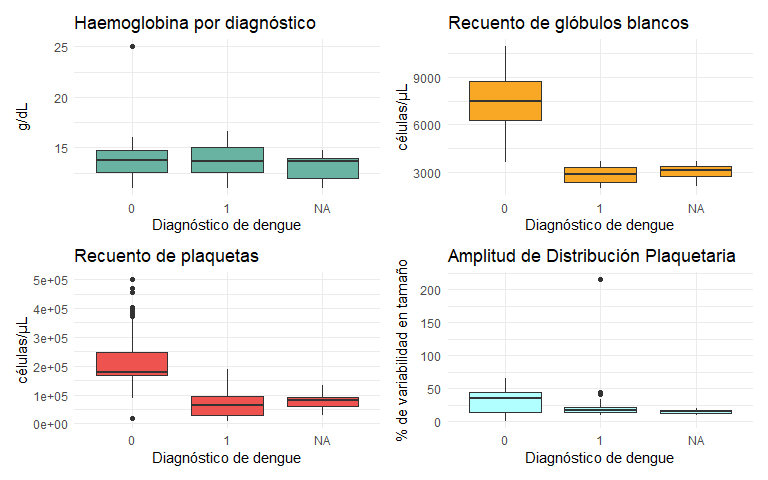

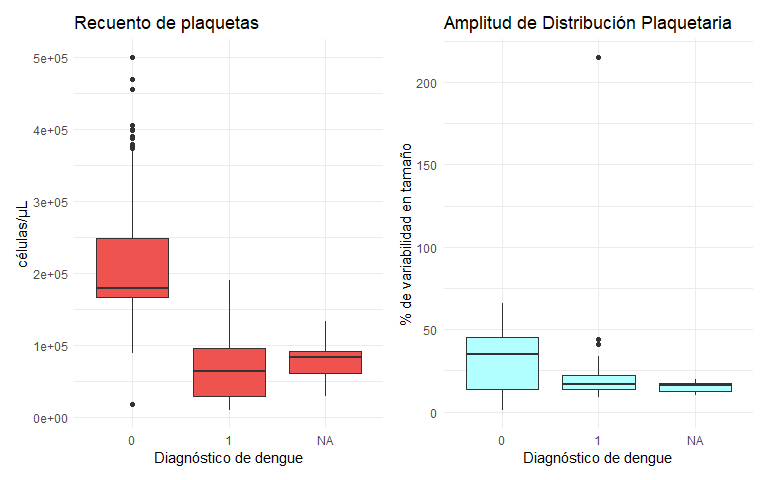

Los diagramas de caja permiten confirmar visualmente los patrones observados en el análisis realizado anteriormente con las tablas. En general, los pacientes con diagnóstico positivo de dengue presentan menores valores en el recuento de glóbulos blancos, recuento de plaquetas y PDW, en comparación con los pacientes sin dengue. Esto sugiere una afectación consistente del sistema hematológico en presencia de la infección, tanto en cantidad celular como en variabilidad morfológica. En contraste, la variable hemoglobina muestra distribuciones similares entre grupos, con medianas cercanas y sin diferencias apreciables.

También se observa una mayor dispersión en los valores de leucocitos, plaquetas y PDW en el grupo sin dengue, lo que podría indicar una mayor heterogeneidad en las respuestas hematológicas entre estos pacientes.

Los gráficos revelan la presencia de valores atípicos, especialmente en el recuento de plaquetas en pacientes sin dengue, con varios casos que superan las 400,000 células/µL. Se observan también outliers en PDW en el grupo positivo, y un valor extremo aislado en hemoglobina. Aunque estos valores no afectan significativamente las medianas, podrían estar relacionados con respuestas fisiológicas particulares, errores de medición o casos clínicos poco comunes.

# Conclusión

A partir de las tablas y gráficos presentados, se observa que variables como el recuento de glóbulos blancos, el recuento de plaquetas y la amplitud de distribución plaquetaria muestran diferencias claras entre los grupos de diagnóstico, lo que sugiere su potencial utilidad en la etapa de modelado. En cambio, variables como la hemoglobina no presentan patrones diferenciales marcados, por lo que podrían tener un menor valor discriminativo.

Dado que algunas variables muestran alta correlación, será importante aplicar estrategias que consideren la multicolinealidad. Las observaciones extraídas en esta etapa exploratoria servirán como base para la definición de un modelo. En particular, la selección de variables y el tratamiento de posibles colinealidades serán aspectos clave para garantizar la validez del enfoque estadístico.